# R174_cln_clst_re

fkeita

2018/9/27

```r
knitr::opts_chunk$set(echo = TRUE, cache = TRUE,cache.lazy = FALSE, echo=TRUE)
source("http://bioconductor.org/biocLite.R")
```

```
## Bioconductor version 3.6 (BiocInstaller 1.28.0), ?biocLite for help
```

```
## A new version of Bioconductor is available after installing the most
##   recent version of R; see http://bioconductor.org/install
```

```r
require("stringr")
require("tidyverse")
require("MASS")
```

```r
# require("ggplot2")
# require("dplyr")
# require("magrittr")
require(extrafont)
loadfonts(quiet = T)

#biocLite("GEOquery")
##require(GEOquery)

set.seed("20180927")
```

```r
d <- data.table::fread(file = "./clst_clin2.csv",sep = ",", header = T, stringsAsFactors = F) %>%
  as.data.frame()

class(d)
```

```
## [1] "data.frame"
```

```r
dt <- d %>%
  t() %>%
  as.data.frame() %>%
  dplyr::mutate(rowname = rownames(.)) %>%
  .[,c(ncol(.), 1:ncol(.) -1)]
# d %>%
#   DT::datatable(caption = "clinicaldata and clust")
```

```r
trimAllNAcol <- function(d){
  na_ind <- colnames(d)[apply(X = d, 2, function(vec){return(sum(!is.na(vec)))}) != 0]

  d <- d %>%
    dplyr::select(one_of(na_ind))

  return(d)
}



colnames(d)[1:4]
```

```
## [1] "V1"          "Row.names"   "clst_result" "V2"
```

```r
getKeyWord <- function(d, clst = "clst_result", key){
  cln_ind <- str_detect(colnames(d), "^Row")

  clst_ind <- str_detect(colnames(d), clst)
  key_ind <- str_detect(colnames(d), key)
  ind <- colnames(d)[cln_ind | clst_ind | key_ind]
  d <- d %>%
    dplyr::select(one_of(ind))
  return(d)
}
clst <- "clst_result"
key <- "ablation"
d_ab <- d %>%
  getKeyWord(key = key) %>%
  trimAllNAcol()

key <- "indicator"
d_ind <- d %>%
  getKeyWord(key = key) %>%
  trimAllNAcol()

key <- "bilirubin"

d_bil <- d %>%
  getKeyWord(key = key) %>%
  trimAllNAcol()

key <- "creatinine"
d_cre <- d %>%
  getKeyWord(key = key) %>%
  trimAllNAcol()
```

```r
dmeta <- d
for(i in 4:ncol(d)){
  col_i <- colnames(d)[i]
  dmeta[[col_i]] <- !is.na(d[[col_i]])
}

class(dmeta)
```

```
## [1] "data.frame"
```

```r
#
# dmeta <- dmeta %>%
#   dplyr::group_by(clst_result)

# i <- 50
# col_i <- colnames(dmeta)[i]

dmeta_i <- dmeta %>%
  `colnames<-`(str_replace_all(colnames(.), "-|\\.", "_")) %>%
  dplyr::summarise(sum(patient_ablations_ablation_2_month_of_form_completion))

  #dplyr::summarise()

#dmeta[,i]
#i <- 15
getClstSum <- function(dmeta, i){
  col_i <- colnames(dmeta)[i]
  dtb <- dmeta %>%
    dplyr::select(one_of(c("clst_result", col_i))) #%>%
  dtb[["col_i"]] <- dtb[[col_i]]
#    mutate(col_i = .[[col_i]])
  sm <- dtb %>%
    group_by(clst_result) %>%
    summarise(sum(col_i))
  colnames(sm)[2] <- col_i
  return(sm)
}

#dmeta[,15]
sm <- getClstSum(dmeta, 4)
for(i in 5:ncol(dmeta)){
  #print(i)
  sm <- cbind(sm, getClstSum(dmeta, i)[,2])
}

smt <- sm %>%
  t() %>%
  as.data.frame() %>%
  dplyr::mutate(labels = rownames(.))

DT::datatable(data = smt, caption = "variable and non-na count\nin two cluster")
```

|  | V1 | V2 | labels |
| --- | --- | --- | --- |
| 1 | 1 | 2 | clst_result |
| 2 | 360 | 11 | V2 |
| 3 | 360 | 11 | sampe_tag |
| 4 | 360 | 11 | admin.batch_number |
| 5 | 360 | 11 | admin.bcr |
| 6 | 360 | 11 | admin.day_of_dcc_upload |
| 7 | 360 | 11 | admin.disease_code |
| 8 | 360 | 11 | admin.file_uuid |
| 9 | 360 | 11 | admin.month_of_dcc_upload |
| 10 | 360 | 11 | admin.patient_withdrawal.withdrawn |

[output cut: 1743 more lines]

```r
setNA2Zero <- function(vec){
  vec0 <- ifelse(is.na(vec), 0, vec)
  return(vec0)
}

setNA2Emp <- function(vec){
  vec0 <- ifelse(is.na(vec), "", vec)
  return(vec0)
}


clstInts2Strs <- function(vec){
  int2str <- function(num){
    if(num ==1){
      return("Major")
    }else if(num ==2){
      return("Minor")
    }else{
      return("Unknown")
    }
  }

  strvec <- sapply(vec, int2str)
  return(strvec)
}



getMat <- function(dat, clst = "clst_result", key){
  d <- dat %>%
    dplyr::filter(!is.na(.[[clst]])) %>%
    dplyr::select(one_of(c(clst, key))) %>%
    dplyr::mutate(!!clst := clstInts2Strs(.[[clst]]))

  smr <- d %>%
    mutate(count = 1) %>%
    group_by_(clst, key) %>%
    summarise(count = sum(count))

  mt <- smr %>%
    tidyr::spread_(key = key, value = "count") %>%
    purrr::map_at(.at = c(2:(ncol(.))), setNA2Zero) %>%
    as.data.frame() %>%
    `rownames<-`(.[[clst]]) %>%
    dplyr::select(-matches(clst)) %>%
    t()

  #    dplyr::select(-ends_with("NA.")) %>%

  return(mt)
}

trimLastNARow <- function(mat){
  lastname <- rownames(mat) %>%
    .[length(.)]
  if(str_detect(lastname, "NA")){
    mat <- mat %>%
      .[c(1:nrow(.) -1),]
  }else{
    print("NA row not detected.")
  }
  return(mat)
}

getChiseqFish <- function(mat){
  print(chisq.test(mat))
  print(fisher.test(mat))
}

checkLab_I <- function(dat, i, get_bool =F){
  key_i <- colnames(dat)[i]
  print(paste("analysing label: ", key_i, sep=""))
  mat_i <- getMat(dat, key = key_i)
  print(htmltools::tagList(
    DT::datatable(data = mat_i, caption = key_i)
  ))

  mat_i %>%
    trimLastNARow() %>%
    getChiseqFish()

  if(get_bool){
    return(mat_i)
  }
}



ggsave2 <- function(plot, wid=9, hei=9){
  plot_name <- deparse(substitute(plot))
  file_name <- paste(plot_name, ".png", sep = "",collapse = "")
  ggsave(filename = file_name,plot = plot,device = "png",width = wid, height = hei,dpi = 300,units = "cm")
}
```

age

```r
key <- "patient.age_at_initial_pathologic_diagnosis"
d_age <- d %>%
  getKeyWord(key = key) %>%
  trimAllNAcol() %>%
  dplyr::filter(!is.na(.[[key]])) %>%
  mutate_(key = key)

age_major <- d_age %>%
  dplyr::filter(clst_result ==1) %>%
  .[[key]]

age_minor <- d_age %>%
  dplyr::filter(clst_result ==2) %>%
  .[[key]]

ks.test(age_major, age_minor)
```

```
##
##  Two-sample Kolmogorov-Smirnov test
##
## data:  age_major and age_minor
## D = 0.18815, p-value = 0.8443
## alternative hypothesis: two-sided
```

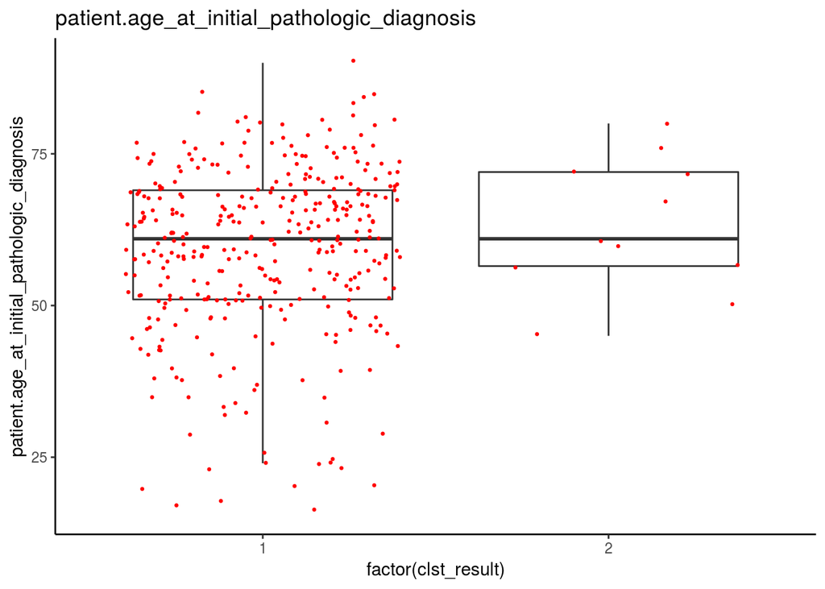

```r
p_age <- ggplot()+theme_classic()+
  geom_boxplot(data = d_age, mapping =  aes(x= factor(clst_result), y = key),outlier.colour = NA) +
  geom_jitter(data = d_age, mapping = aes(x= factor(clst_result), y = key), color ="red", size = 0.5) +
  ylab(key) +ggtitle(key)
p_age
```

```r
ggsave2(p_age, wid = 9)
```

```r
key <- "patient.neoplasm_histologic_grade"
d_hist <- d %>%
  getKeyWord(key = key) %>%
  mutate_(key = key)


mt <- checkLab_I(d_hist, i = 3, get_bool = T)
```

[1] “analysing label: patient.neoplasm_histologic_grade”

|  | Major | Minor |
| --- | --- | --- |
| g1 | 54 | 1 |
| g2 | 172 | 5 |
| g3 | 118 | 4 |
| g4 | 12 | 0 |
| X.NA. | 4 | 1 |

```
Pearson's Chi-squared test
```

data: mat X-squared = 0.65278, df = 3, p-value = 0.8842

```
Fisher's Exact Test for Count Data
```

data: mat p-value = 1 alternative hypothesis: two.sided

```r
key <- "patient.history_of_neoadjuvant_treatment"
d_nac <- d %>%
  getKeyWord(key = key) %>%
  mutate_(key = key)

checkLab_I(d_nac, i = 3)
```

[1] “analysing label: patient.history_of_neoadjuvant_treatment”

|  | Major | Minor |
| --- | --- | --- |
| no | 358 | 11 |
| yes | 2 | 0 |

[1] “NA row not detected.”

```
Pearson's Chi-squared test with Yates' continuity correction
```

data: mat X-squared = 2.3543e-30, df = 1, p-value = 1

```
Fisher's Exact Test for Count Data
```

data: mat p-value = 1 alternative hypothesis: true odds ratio is not equal to 1 95 percent confidence interval: 0.0000 181.1444 sample estimates: odds ratio 0

```r
key <- "patient.child_pugh_classification_grade"

d_cp <- d %>%
  getKeyWord(key = key) %>%
  mutate_(key = key)

checkLab_I(d_cp, i = 3)
```

[1] “analysing label: patient.child_pugh_classification_grade”

|  | Major | Minor |
| --- | --- | --- |
| a | 216 | 1 |
| b | 21 | 0 |
| c | 1 | 0 |
| X.NA. | 122 | 10 |

```
Pearson's Chi-squared test
```

data: mat X-squared = 0.10181, df = 2, p-value = 0.9504

```
Fisher's Exact Test for Count Data
```

data: mat p-value = 1 alternative hypothesis: two.sided patient.fibrosis_ishak_score

```r
key <- "patient.fibrosis_ishak_score"

d_fib <- d %>%
  getKeyWord(key = key) %>%
  mutate_(key = key)

checkLab_I(d_fib, i = 3)
```

[1] “analysing label: patient.fibrosis_ishak_score”

|  | Major | Minor |
| --- | --- | --- |
| X0...no.fibrosis | 72 | 2 |
| X1.2...portal.fibrosis | 31 | 0 |
| X3.4...fibrous.speta | 28 | 0 |
| X5...nodular.formation.and.incomplete.cirrhosis | 8 | 1 |
| X6...established.cirrhosis | 70 | 0 |
| X.NA. | 151 | 8 |

```
Pearson's Chi-squared test
```

data: mat X-squared = 8.7961, df = 4, p-value = 0.0664

```
Fisher's Exact Test for Count Data
```

data: mat p-value = 0.1136 alternative hypothesis: two.sided

```r
key <- "patient.specimen_collection_method_name"

d_ope <- d %>%
  getKeyWord(key = key) %>%
  mutate_(key = key)

checkLab_I(d_ope, i = 3)
```

[1] “analysing label: patient.specimen_collection_method_name”

|  | Major | Minor |
| --- | --- | --- |
| extended.lobectomy | 22 | 3 |
| lobectomy | 137 | 5 |
| other..specify. | 24 | 2 |
| segmentectomy..multiple | 86 | 1 |
| segmentectomy..single | 87 | 0 |
| total.hepatectomy.with.transplant | 1 | 0 |
| X.NA. | 3 | 0 |

```
Pearson's Chi-squared test
```

data: mat X-squared = 12.849, df = 5, p-value = 0.02484

```
Fisher's Exact Test for Count Data
```

data: mat p-value = 0.01807 alternative hypothesis: two.sided

```r
key <- "patient.histological_type"

d_hit <- d %>%
  getKeyWord(key = key) %>%
  mutate_(key = key)

checkLab_I(d_hit, i = 3)
```

[1] “analysing label: patient.histological_type”

|  | Major | Minor |
| --- | --- | --- |
| fibrolamellar.carcinoma | 3 | 0 |
| hepatocellular.carcinoma | 351 | 10 |
| hepatocholangiocarcinoma..mixed. | 6 | 1 |

[1] “NA row not detected.”

```
Pearson's Chi-squared test
```

data: mat X-squared = 3.2575, df = 2, p-value = 0.1962

```
Fisher's Exact Test for Count Data
```

data: mat p-value = 0.2627 alternative hypothesis: two.sided

```r
key <- "patient.prothrombin_time_result_value"

d_pt <- d %>%
  getKeyWord(key = key) %>%
  mutate_(key = key)

x <- d_pt %>%
  dplyr::filter(clst_result == 1) %>%
  .[[key]]
y <- d_pt %>%
  dplyr::filter(clst_result == 2) %>%
  .[[key]]

ks.test(x, y)
```

```
Two-sample Kolmogorov-Smirnov test
```

data: x and y D = 0.25121, p-value = 0.9157 alternative hypothesis: two-sided

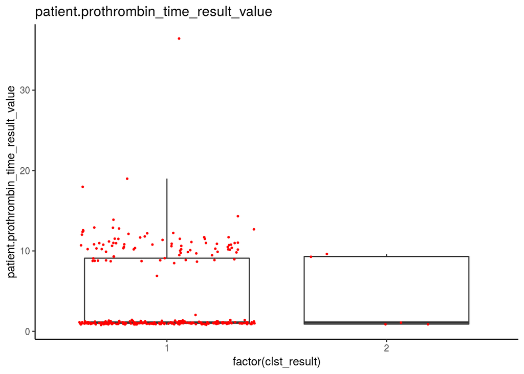

```r
p_pt_boxjit <- ggplot()+theme_classic()+
  geom_boxplot(data = d_pt, mapping =  aes(x= factor(clst_result), y = key),outlier.colour = NA) +
  geom_jitter(data = d_pt, mapping = aes(x= factor(clst_result), y = key), color ="red", size = 0.5) +
  ylab(key)+ggtitle(key)

p_pt_boxjit
```

```r
ggsave2(p_pt_boxjit, wid = 9)
```

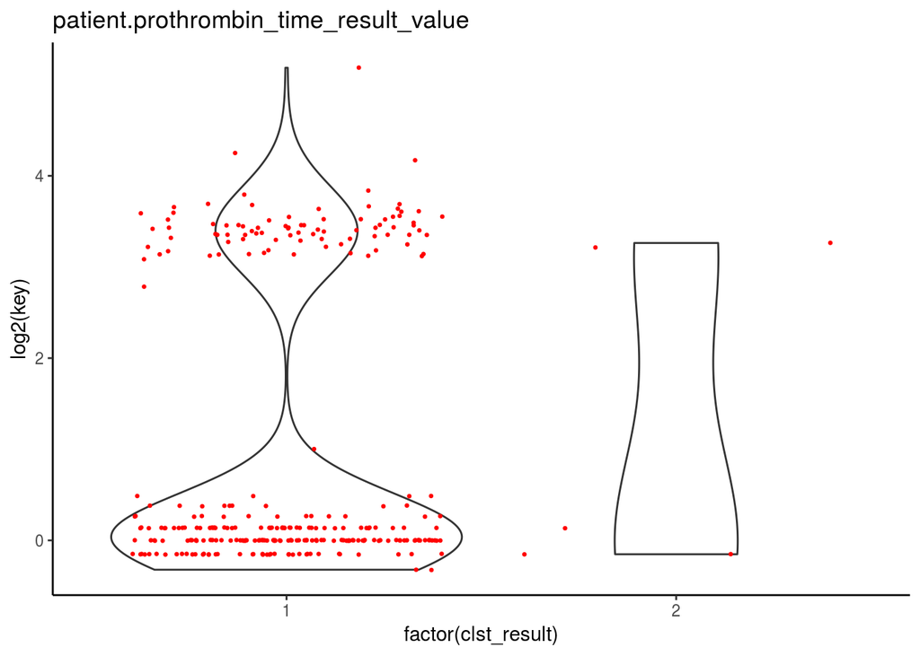

```r
p_pt_logvio <- ggplot()+theme_classic()+
  geom_violin(data = d_pt, mapping = aes(x= factor(clst_result), y = log2(key))) +
  geom_jitter(data = d_pt, mapping = aes(x= factor(clst_result), y = log2(key)), color ="red", size = 0.5) +
  ggtitle(key)
p_pt_logvio
```

```r
ggsave2(p_pt_logvio)
key <- "patient.bilirubin_upper_limit"

d_bil <- d %>%
  getKeyWord(key = key) %>%
  mutate_(key = key)

x <- d_bil %>%
  dplyr::filter(clst_result == 1) %>%
  .[[key]]
y <- d_bil %>%
  dplyr::filter(clst_result == 2) %>%
  .[[key]]

ks.test(x, y)
```

```
##
##  Two-sample Kolmogorov-Smirnov test
##
## data:  x and y
## D = 0.66216, p-value = 0.02682
## alternative hypothesis: two-sided
```

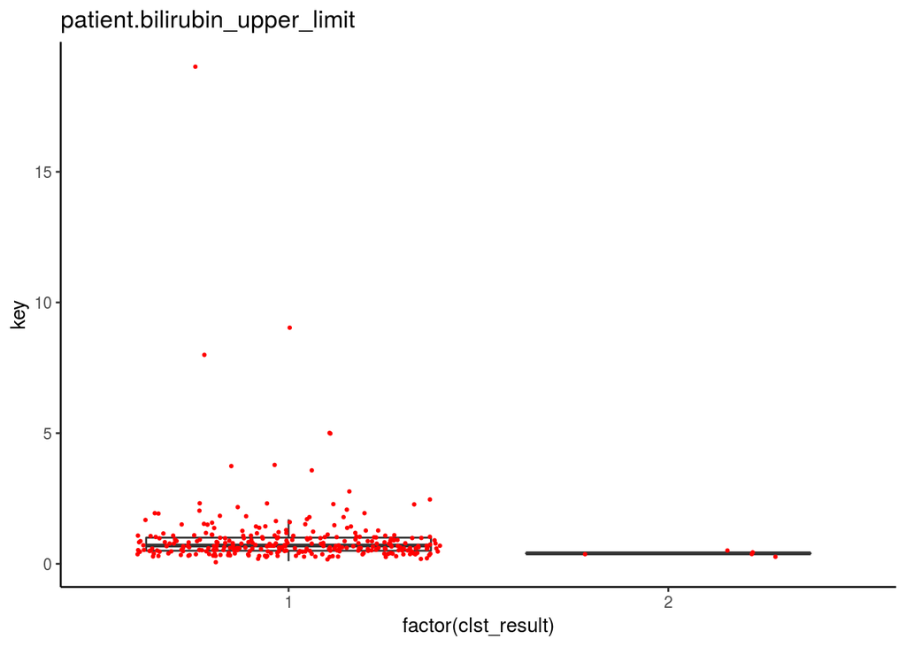

```r
p_bil_boxjit <- ggplot()+theme_classic()+
  geom_boxplot(data = d_bil, mapping =  aes(x= factor(clst_result), y = key),outlier.colour = NA) +
  geom_jitter(data = d_bil, mapping = aes(x= factor(clst_result), y = key), color ="red", size = 0.5) +
  ggtitle(key)

p_bil_boxjit
```

```r
ggsave2(p_bil_boxjit)
```

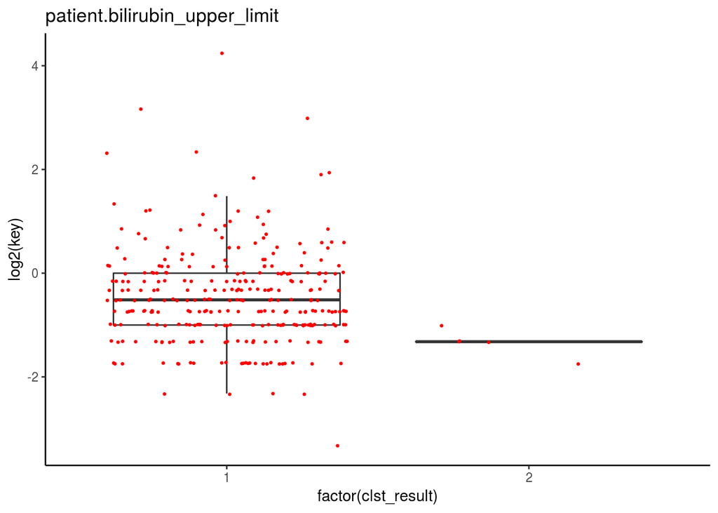

```r
p_bil_log_boxjit <- ggplot()+theme_classic()+
  geom_boxplot(data = d_bil, mapping =  aes(x= factor(clst_result), y = log2(key)),outlier.colour = NA) +
  geom_jitter(data = d_bil, mapping = aes(x= factor(clst_result), y = log2(key)), color ="red", size = 0.5) +
  ggtitle(key)

p_bil_log_boxjit
```

```r
key <- "patient.albumin_result_specified_value"

d_alb <- d %>%
  getKeyWord(key = key) %>%
  mutate_(key = key)

d_alb %>%
  t() %>%
  as.data.frame() %>%
  DT::datatable(data = ., caption = "alb table")
```

|  | V1 | V2 | V3 | V4 | V5 | V6 | V7 | V8 | V9 | V10 | V11 | V12 | V13 | V14 | V15 | V16 | V17 | V18 | V19 | V20 | V21 | V22 | V23 | V24 | V25 | V26 | V27 | V28 | V29 | … |
| --- | --- | --- | --- | --- | --- | --- | --- | --- | --- | --- | --- | --- | --- | --- | --- | --- | --- | --- | --- | --- | --- | --- | --- | --- | --- | --- | --- | --- | --- | --- |
| Row.names | TCGA-2V-A95S | TCGA-2Y-A9GS | TCGA-2Y-A9GT | TCGA-2Y-A9GU | TCGA-2Y-A9GV | TCGA-2Y-A9GW | TCGA-2Y-A9GX | TCGA-2Y-A9GY | TCGA-2Y-A9GZ | TCGA-2Y-A9H0 | TCGA-2Y-A9H1 | TCGA-2Y-A9H2 | TCGA-2Y-A9H3 | TCGA-2Y-A9H4 | TCGA-2Y-A9H5 | TCGA-2Y-A9H6 | TCGA-2Y-A9H7 | TCGA-2Y-A9H8 | TCGA-2Y-A9H9 | TCGA-2Y-A9HA | TCGA-2Y-A9HB | TCGA-3K-AAZ8 | TCGA-4R-AA8I | TCGA-5C-A9VG | TCGA-5C-A9VH | TCGA-5C-AAPD | TCGA-5R-AA1C | TCGA-5R-AA1D | TCGA-5R-AAAM | … |
| clst_result | 1 | 1 | 1 | 1 | 1 | 1 | 1 | 1 | 1 | 1 | 1 | 1 | 1 | 1 | 1 | 1 | 1 | 1 | 1 | 1 | 1 | 1 | 1 | 1 | 1 | 1 | 1 | 1 | 1 | … |
| patient.albumin_result_specified_value | 4.2 | 4.0 | 3.7 | 4.4 | 4.2 | 4.5 | 4.3 | 4.2 | 4.5 | 2.0 | 4.4 | 4.5 | 5.3 | 4.6 | 4.9 | 4.0 | 3.4 | 4.2 | 4.7 | 3.5 | 3.9 |  | 3.8 |  |  |  | 3.0 | 3.3 | 3.0 | … |
| key | 4.2 | 4.0 | 3.7 | 4.4 | 4.2 | 4.5 | 4.3 | 4.2 | 4.5 | 2.0 | 4.4 | 4.5 | 5.3 | 4.6 | 4.9 | 4.0 | 3.4 | 4.2 | 4.7 | 3.5 | 3.9 |  | 3.8 |  |  |  | 3.0 | 3.3 | 3.0 | … |

```r
#max(d_alb$patient.albumin_result_specified_value)


x <- d_alb %>%
  dplyr::filter(clst_result == 1) %>%
  .[[key]]
y <- d_alb %>%
  dplyr::filter(clst_result == 2) %>%
  .[[key]]

ks.test(x, y)
```

```
##
##  Two-sample Kolmogorov-Smirnov test
##
## data:  x and y
## D = 0.53425, p-value = 0.1208
## alternative hypothesis: two-sided
```

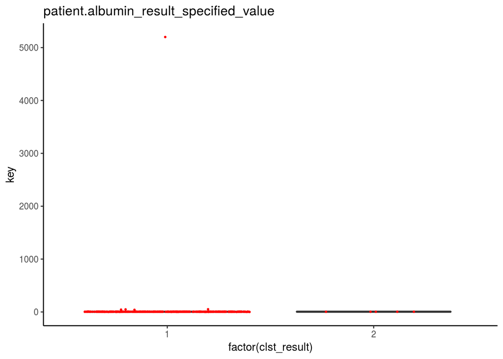

```r
p_alb_boxjit <- ggplot()+theme_classic()+
  geom_boxplot(data = d_alb, mapping =  aes(x= factor(clst_result), y = key),outlier.colour = NA) +
  geom_jitter(data = d_alb, mapping = aes(x= factor(clst_result), y = key), color ="red", size = 0.5) +
  ggtitle(key)

p_alb_boxjit
```

```r
ggsave2(p_alb_boxjit)
```

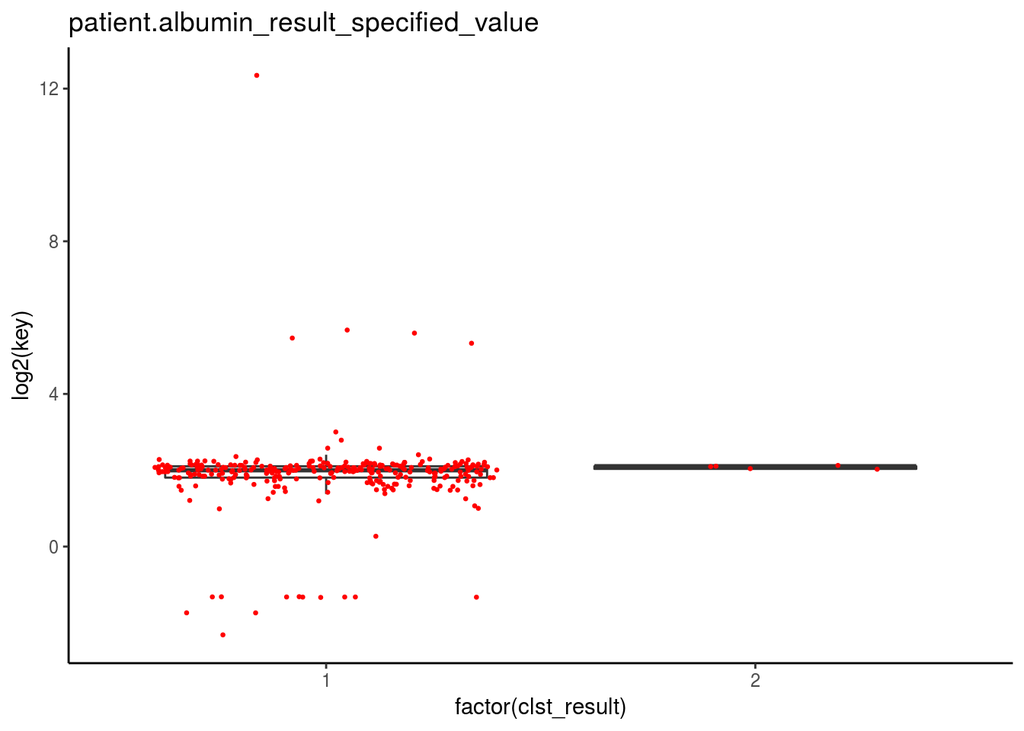

```r
p_alb_log2_boxjit <- ggplot()+theme_classic()+
  geom_boxplot(data = d_alb, mapping =  aes(x= factor(clst_result), y = log2(key)),outlier.colour = NA) +
  geom_jitter(data = d_alb, mapping = aes(x= factor(clst_result), y = log2(key)), color ="red", size = 0.5) +
  ggtitle(key)

p_alb_log2_boxjit
```

```r
ggsave2(p_alb_log2_boxjit)
```

```r
getI <- function(vec, i){
  return(vec[i])
}

multiRep2 <- function(x, pairs){
  # x
  # pairs is list of pair vector
  #stopifnot(length(pairs != 0))
  pre <- lapply(pairs, getI, i=1) %>%
    unlist()
  after <- lapply(pairs, getI, i=2) %>%
    unlist()
  ind <- match(x, pre)
  return(ifelse(is.na(ind), x, after[ind]))
}

apedl <- function(l, c1, c2){
  l <- append(l, list(c(c1, c2)))
  return(l)
}

r_pairs <- list() %>%
  apedl("hbcab total (+), hbsag (-), hbcigm ab (-)", "HBV infection history") %>%
  apedl("chronic hepatitis, either viral or autoimmune", "unknown chronic hepatitis") %>%
  apedl("tobacco use", "tobacco") %>%
  apedl("liver cirrhosis", "cirrhosis") %>%
  apedl("male, iddm for 30+years", "DM") %>%
  apedl("moderate alcohol consumption", "alcohol consumption") %>%
  apedl("no", "no history of primary risk factors") %>%
  apedl("anti tb drug used for tb positive testing", "anti TB drug") %>%
  apedl("moderate alcohol use on weekends", "alcohol consumption") %>%
  apedl("alcohol abuse", "alcohol consumption") %>%
  apedl("former smoker", "tobacco") %>%
  apedl("smoking", "tobacco") %>%
  apedl("smoker", "tobacco") %>%
  apedl("extensive tobacco history", "tobacco") %>%
  apedl("tabacco", "tobacco")
```

## risk

```r
tag_vec <- c("clst_result",colnames(d)[str_detect(colnames(d), "risk")])
d_risk <- d %>%
  dplyr::select(one_of(tag_vec)) %>%
  `colnames<-`(c("clst_result", "risk1", "risk2", "risk3", "risk4", "risk5")) %>%
  mutate(risk_all = ifelse(is.na(risk1) &
                             is.na(risk2) &
                             is.na(risk3) &
                             is.na(risk4) &
                             is.na(risk5), "no description of primary risk factors", NA))

d_risk_long <- NULL
for(i in 2:7){
  d_i <- d_risk[,c(1,i)] %>%
    `colnames<-`(c("clst_result", "risk_factor"))
  d_risk_long <- rbind(d_risk_long, d_i)
}
d_risk_long <- d_risk_long %>%
  dplyr::filter(!is.na(risk_factor)) %>%
  mutate(comma_count = str_count(risk_factor, ",")) %>%
  mutate(risk_factor_clean = multiRep2(risk_factor, r_pairs)) %>%
  mutate(comma_count2 = str_count(risk_factor_clean, ",")) %>%
  filter(risk_factor != "other")

d_risk_long2 <- NULL
#i <- 409
for(i in 1: nrow(d_risk_long)){
  row_i <- d_risk_long[i,]
  if(row_i$comma_count2 ==0){
    d_risk_long2 <- rbind(d_risk_long2, row_i)
  }else{
    wds <- str_split(row_i$risk_factor_clean, ", ")[[1]]
    row_i2 <- row_i
    row_i2$risk_factor_clean <- wds[2]
    row_i$risk_factor_clean <- wds[1]
    d_risk_long2 <- rbind(d_risk_long2, row_i, row_i2)
  }
}

d_risk_long2 <- d_risk_long2 %>%
  mutate(risk_factor_clean2 = multiRep2(risk_factor_clean, r_pairs))




mt <- checkLab_I(d_risk_long2, i = 6, get_bool = T) %>%
  `rownames<-`(str_replace_all(rownames(.), "\\.", "_"))
```

[output not shown]

```
##
##  Pearson's Chi-squared test
##
## data:  mat
## X-squared = 12.919, df = 23, p-value = 0.9537
##
##
##  Fisher's Exact Test for Count Data
##
## data:  mat
## p-value = 0.3441
## alternative hypothesis: two.sided
```

```r
DT::datatable(data = mt, caption = "risk_factors_multiple choices allowed")
```

|  | Major | Minor |
| --- | --- | --- |
| alcohol_consumption | 117 | 4 |
| alpha_1_antitrypsin_deficiency | 1 | 0 |
| anti_TB_drug | 1 | 0 |
| birth_control_bills | 1 | 0 |
| cirrhosis | 4 | 0 |
| cryptogenic_cirrhosis | 1 | 0 |
| DM | 1 | 0 |
| gilbert_s_syndrome_ | 1 | 0 |
| HBV_infection_history | 1 | 0 |
| hemochromatosis | 7 | 0 |

[output cut: 14 more lines]

```r
key <- "patient.height"

d_hei <- d %>%
  getKeyWord(key = key) %>%
  mutate_(key = key)


x <- d_hei %>%
  dplyr::filter(clst_result == 1) %>%
  .[[key]]
y <- d_hei %>%
  dplyr::filter(clst_result == 2) %>%
  .[[key]]

ks.test(x, y)
```

```
##
##  Two-sample Kolmogorov-Smirnov test
##
## data:  x and y
## D = 0.33838, p-value = 0.2683
## alternative hypothesis: two-sided
```

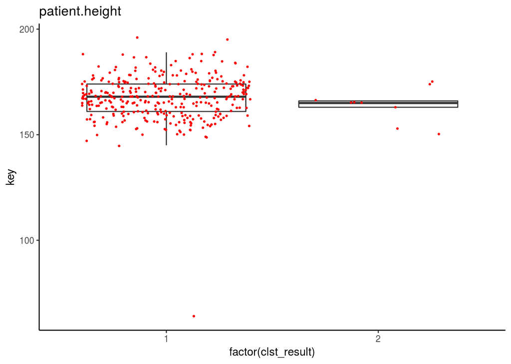

```r
p_hei_boxjit <- ggplot()+theme_classic()+
  geom_boxplot(data = d_hei, mapping =  aes(x= factor(clst_result), y = key),outlier.colour = NA) +
  geom_jitter(data = d_hei, mapping = aes(x= factor(clst_result), y = key), color ="red", size = 0.5) +
  ggtitle(key)

p_hei_boxjit
```

```r
ggsave2(p_hei_boxjit)
key <- "patient.weight"

d_wei <- d %>%
  getKeyWord(key = key) %>%
  mutate_(key = key)


x <- d_wei %>%
  dplyr::filter(clst_result == 1) %>%
  .[[key]]
y <- d_wei %>%
  dplyr::filter(clst_result == 2) %>%
  .[[key]]

ks.test(x, y)
```

```
##
##  Two-sample Kolmogorov-Smirnov test
##
## data:  x and y
## D = 0.49718, p-value = 0.02626
## alternative hypothesis: two-sided
```

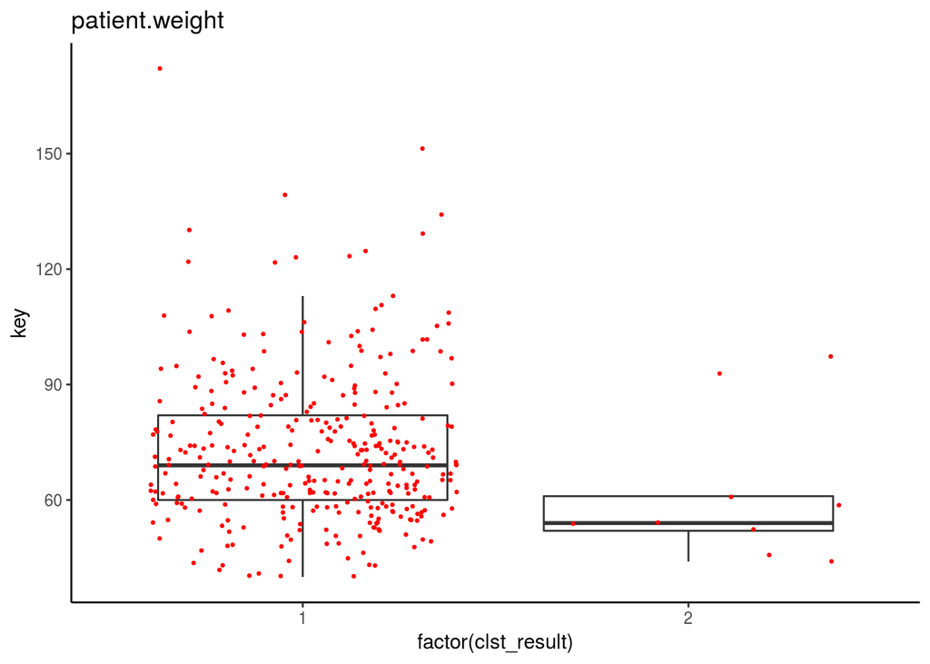

```r
p_wei_boxjit <- ggplot()+theme_classic()+
  geom_boxplot(data = d_wei, mapping =  aes(x= factor(clst_result), y = key),outlier.colour = NA) +
  geom_jitter(data = d_wei, mapping = aes(x= factor(clst_result), y = key), color ="red", size = 0.5) +
  ggtitle(key)

p_wei_boxjit
```

```r
ggsave2(p_wei_boxjit)
d$bmi <- d$patient.weight / (d$patient.height/100)^2
sum(is.na(d$bmi))
```

```
## [1] 36
```

```r
key <- "bmi"

d_bmi <- d %>%
  getKeyWord(key = key) %>%
  mutate_(key = key)


x <- d_bmi %>%
  dplyr::filter(clst_result == 1) %>%
  .[[key]]
y <- d_bmi %>%
  dplyr::filter(clst_result == 2) %>%
  .[[key]]

ks.test(x, y)
```

```
##
##  Two-sample Kolmogorov-Smirnov test
##
## data:  x and y
## D = 0.54772, p-value = 0.01044
## alternative hypothesis: two-sided
```

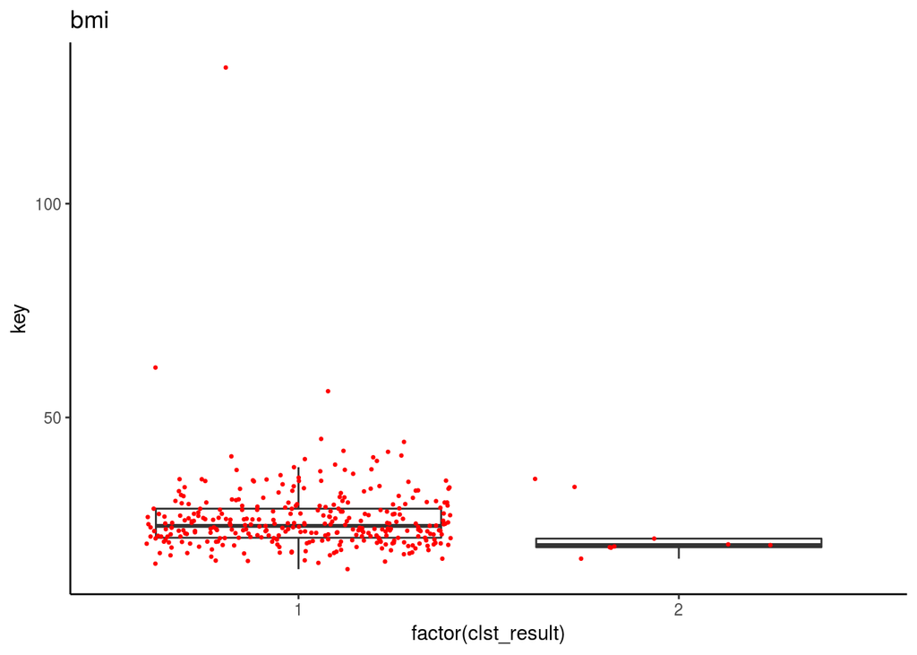

```r
p_bmi_boxjit <- ggplot()+theme_classic()+
  geom_boxplot(data = d_bmi, mapping =  aes(x= factor(clst_result), y = key),outlier.colour = NA) +
  geom_jitter(data = d_bmi, mapping = aes(x= factor(clst_result), y = key), color ="red", size = 0.5) +
  ggtitle(key)

p_bmi_boxjit
```

```r
ggsave2(p_bmi_boxjit)
key <- "patient.platelet_result_count"

d_plt <- d %>%
  getKeyWord(key = key) %>%
  mutate_(key = key)


x <- d_plt %>%
  dplyr::filter(clst_result == 1) %>%
  .[[key]]
y <- d_plt %>%
  dplyr::filter(clst_result == 2) %>%
  .[[key]]

ks.test(x, y)
```

```
##
##  Two-sample Kolmogorov-Smirnov test
##
## data:  x and y
## D = 0.33846, p-value = 0.6262
## alternative hypothesis: two-sided
```

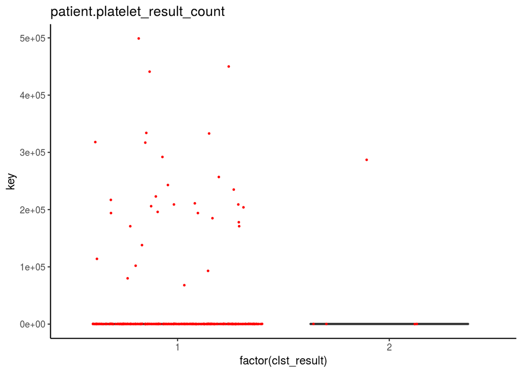

```r
p_plt_boxjit <- ggplot()+theme_classic()+
  geom_boxplot(data = d_plt, mapping =  aes(x= factor(clst_result), y = key),outlier.colour = NA) +
  geom_jitter(data = d_plt, mapping = aes(x= factor(clst_result), y = key), color ="red", size = 0.5) +
  ggtitle(key)

p_plt_boxjit
```

```r
ggsave2(p_plt_boxjit)
```

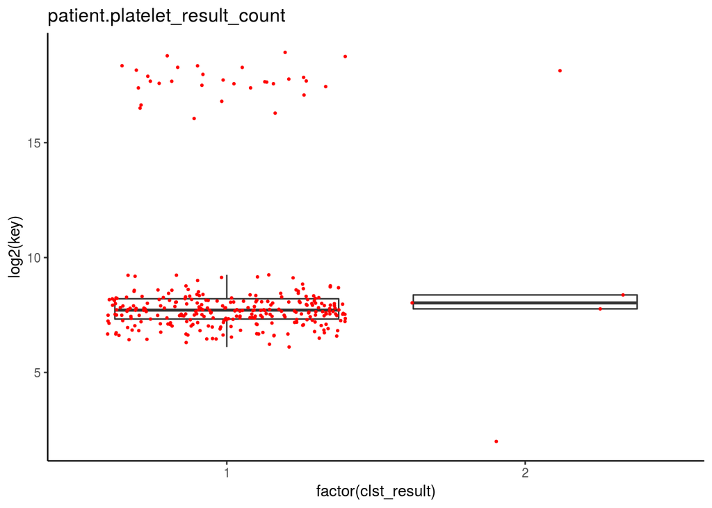

```r
p_plt_log2_boxjit <- ggplot()+theme_classic()+
  geom_boxplot(data = d_plt, mapping =  aes(x= factor(clst_result), y = log2(key)),outlier.colour = NA) +
  geom_jitter(data = d_plt, mapping = aes(x= factor(clst_result), y = log2(key)), color ="red", size = 0.5) +
  ggtitle(key)

p_plt_log2_boxjit
```

```r
ggsave2(p_plt_log2_boxjit)
key <- "patient.fetoprotein_outcome_value"

d_afp <- d %>%
  getKeyWord(key = key) %>%
  mutate_(key = key)


x <- d_afp %>%
  dplyr::filter(clst_result == 1) %>%
  .[[key]]
y <- d_afp %>%
  dplyr::filter(clst_result == 2) %>%
  .[[key]]

ks.test(x, y)
```

```
##
##  Two-sample Kolmogorov-Smirnov test
##
## data:  x and y
## D = 0.39758, p-value = 0.7362
## alternative hypothesis: two-sided
```

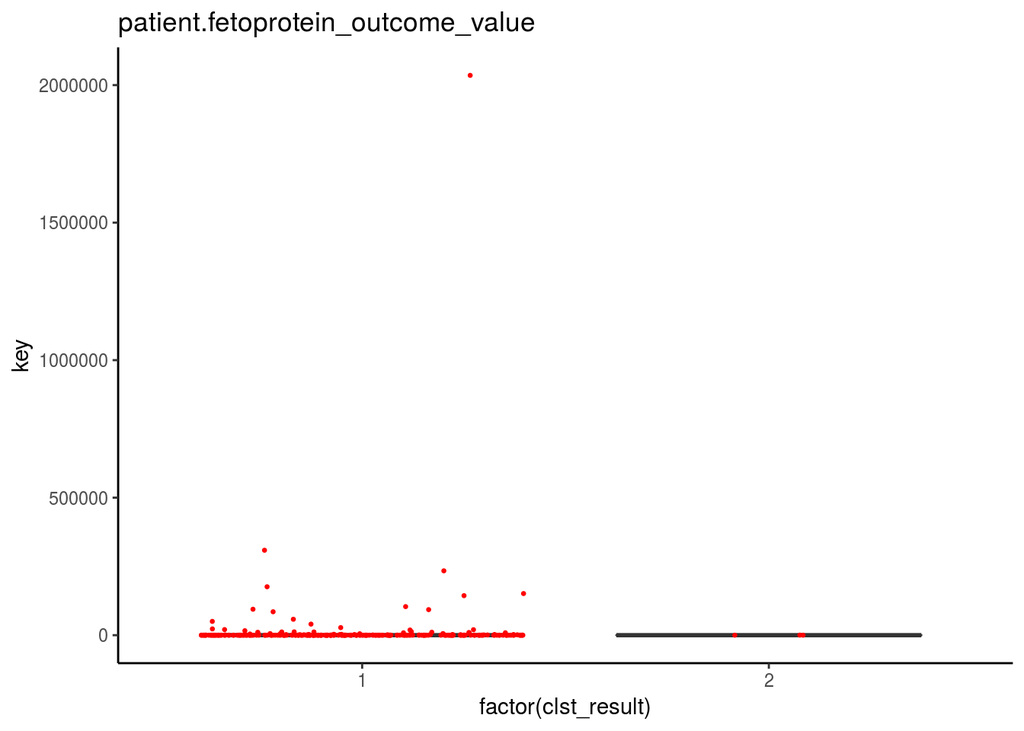

```r
p_afp_boxjit <- ggplot()+theme_classic()+
  geom_boxplot(data = d_afp, mapping =  aes(x= factor(clst_result), y = key),outlier.colour = NA) +
  geom_jitter(data = d_afp, mapping = aes(x= factor(clst_result), y = key), color ="red", size = 0.5) +
  ggtitle(key)

p_afp_boxjit
```

```r
ggsave2(p_afp_boxjit)
```

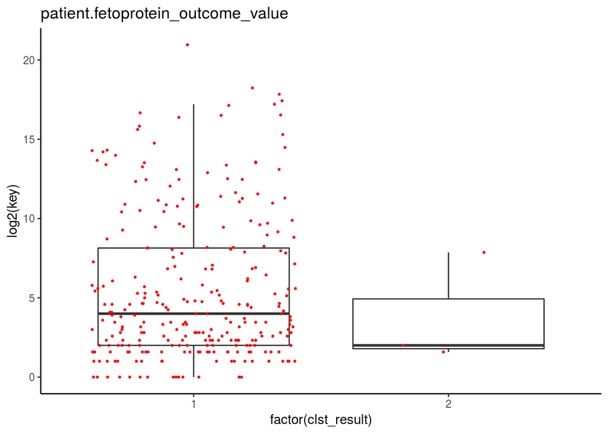

```r
p_afp_log_boxjit <- ggplot()+theme_classic()+
  geom_boxplot(data = d_afp, mapping =  aes(x= factor(clst_result), y = log2(key)),outlier.colour = NA) +
  geom_jitter(data = d_afp, mapping = aes(x= factor(clst_result), y = log2(key)), color ="red", size = 0.5) +
  ggtitle(key)

p_afp_log_boxjit
```

```r
pt_abn <- d %>%
  dplyr::filter(Row.names =="TCGA-DD-A4NR") %>%
  t() %>%
  as.data.frame() %>%
  mutate(rown = rownames(.)) %>%
  dplyr::filter(!is.na(V1))
```

```r
Sys.time()
```

```
## [1] "2018-10-02 00:41:36 UTC"
```

```r
Sys.info()
```

```
##                                        sysname
##                                        "Linux"
##                                        release
##                            "4.4.0-134-generic"
##                                        version
## "#160-Ubuntu SMP Wed Aug 15 14:58:00 UTC 2018"
##                                       nodename
##                                     "dry16was"
##                                        machine
##                                       "x86_64"
##                                          login
##                                      "unknown"
##                                           user
##                                       "r-user"
##                                 effective_user
##                                       "r-user"
```

## function for save attached pkgs from sessioninfo

```r
ses2ris <- function(dir="./ses_ris", ver=T){
  require("magrittr")
  require("stringr")

  if(!file.exists(dir)){
    dir.create(dir)
  }

  end_out <- function(pac, ver, dir){
    pac_ver <- packageVersion(pac)

    if(ver){
      out_file <- paste(pac, "_", pac_ver, ".ris",sep = "")
    }else{
      out_file <- paste(pac, ".ris",sep = "")
    }
    print(out_file)

    ##pac_cit <- utils:::print.bibentry(citation(pac), style = "Bibtex")
    pac_cit <- print(citation(pac),bibtex=TRUE)

    double_q <- "\""
    if(!is.na(pac_cit[1]$title)){
      pac_cit[1]$title <- str_replace(pac_cit[1]$title, "---", ":")
      pac_cit[1]$title <- str_replace_all(pac_cit[1]$title, "\\'", double_q)
    }

    capture.output(toBibtex(pac_cit),file = "tmp.bib")

    sys_code <- paste("bib2xml tmp.bib | xml2ris  > ", dir, "/", out_file, sep="")
    print(sys_code)
    system(sys_code)
  }

  pacs <- sessionInfo() %>%
    .$otherPkgs %>%
    names(.)
  print(pacs)
  sapply(X = pacs, FUN = end_out, ver=ver, dir=dir)

  file.remove("./tmp.bib")
}

ses2ris()
```

[output not shown]

[output cut: 194 more lines]

[output not shown]

[output not shown]

```
## [1] TRUE
```